# Full Study Data Analysis

2023-09-07

Load data

```r
rating <- read.csv('data/ratings_with_change.csv')
applicant <- read.csv('data/applications.csv')
IAT <- read.csv('data/IAT_score.csv')
time <- read.csv('data/focus_time_with_change.csv')
```

Combine datasets

```r
df <- merge(rating, applicant, by.x='applicant_id', by.y='id')

df <- merge(df, time, by=c("user_id", "applicant_id"))

df <- merge(df, IAT, by="user_id")
```

Check distribution

```r
t1 <- df %>%
  group_by(user_id) %>%
  summarize(min = (min(total_before)),
            max = (max(total_before)),
            mean = mean(total_before))
summary(t1)
```

```
##     user_id           min               max              mean
##  Min.   : 2.00   Min.   :0.02195   Min.   : 0.589   Min.   :0.2178
##  1st Qu.:22.50   1st Qu.:0.62642   1st Qu.: 2.765   1st Qu.:1.3800
##  Median :45.00   Median :1.29120   Median : 5.748   Median :2.8335
##  Mean   :43.88   Mean   :1.64867   Mean   : 6.137   Mean   :3.1286
##  3rd Qu.:64.50   3rd Qu.:2.53529   3rd Qu.: 8.386   3rd Qu.:4.3540
##  Max.   :85.00   Max.   :5.91572   Max.   :21.827   Max.   :9.1947
```

```r
t1 <- t1 %>%
  summarise(mean_min=mean(min),
            mean_max=mean(max),
            mean_mean=mean(mean))
t1
```

```
## # A tibble: 1 × 3
##   mean_min mean_max mean_mean
##      <dbl>    <dbl>     <dbl>
## 1     1.65     6.14      3.13
```

```r
t2 <- df %>%
  group_by(user_id) %>%
  summarize(min = (min(rating_before)),
            max = (max(rating_before)),
            mean = mean(rating_before))
summary(t2)
```

```
##     user_id           min             max              mean
##  Min.   : 2.00   Min.   : 1.00   Min.   : 66.00   Min.   :36.92
##  1st Qu.:22.50   1st Qu.:27.00   1st Qu.: 94.00   1st Qu.:64.00
##  Median :45.00   Median :45.00   Median : 97.00   Median :74.92
##  Mean   :43.88   Mean   :43.97   Mean   : 95.11   Mean   :71.81
##  3rd Qu.:64.50   3rd Qu.:60.00   3rd Qu.:100.00   3rd Qu.:78.75
##  Max.   :85.00   Max.   :80.00   Max.   :100.00   Max.   :92.50
```

```r
t2 <- t2 %>%
  summarise(mean_min=mean(min),
            mean_max=mean(max),
            mean_mean=mean(mean))
t2
```

```
## # A tibble: 1 × 3
##   mean_min mean_max mean_mean
##      <dbl>    <dbl>     <dbl>
## 1     44.0     95.1      71.8
```

# 1 Data process: normalize by participant

Define normalization function

```r
norm <- function(x) {
  min <- min(x)
  max <- max(x)
  r <- max-min
  norm_x <- 0
  if (r==0) {
    # if all numbers in x are 0, norm_x = 0
  }
  else {
    #else norm_x = (x - min)/(max - min)
    for (i in 1:length(x)) {
      norm_x[i]<- (x[i] - min)/r
    }
  }
  return(norm_x)
}
```

## 1.1 Rating

```r
for (i in unique(df$user_id)) {
  df[df$user_id==i, 'norm_rating_before'] <- norm(df[df$user_id==i, ]$rating_before)
  df[df$user_id==i, 'norm_rating_after'] <- norm(df[df$user_id==i, ]$rating_after)
  df[df$user_id==i, 'norm_rating_change'] <- norm(df[df$user_id==i, ]$rating_change)
}
```

## 1.2 Total Focus Time

```r
for (i in unique(df$user_id)) {
  df[df$user_id==i, 'norm_total_before'] <- norm(df[df$user_id==i, ]$total_before)
  df[df$user_id==i, 'norm_total_after'] <- norm(df[df$user_id==i, ]$total_after)
  df[df$user_id==i, 'norm_total_change'] <- norm(df[df$user_id==i, ]$total_change)
}
```

```r
write.csv(df,'full_study_processed.csv')
```

# 2 H1

Applicants’ gender and race will impact their evaluations

```r
h1 <- df
```

## 2.1 H1.1

Female and non-binary applicants will get less review time than male applicants.

### 2.1.1 Delta Mean Time

Mean focus time (after normalization) by gender:  
Female 0.2870896 Male 0.3657257 Non-binary 0.3812948

Delta mean time (M-F) is 0.07863, p-value=0.00167  
Delta mean time (M-NB) is -0.01556, p-value=0.5473

```r
r1<- h1 %>%
  group_by(GENDER) %>%
  summarise(aver_time = mean(norm_total_before))
r1
```

```
## # A tibble: 3 × 2
##   GENDER     aver_time
##   <chr>          <dbl>
## 1 Female         0.287
## 2 Male           0.366
## 3 Non-binary     0.381
```

```r
print(paste0('Delta mean time (M-F) is ', r1[2,2]-r1[1,2]))
```

```
## [1] "Delta mean time (M-F) is 0.0786361586202942"
```

```r
print(paste0('Delta mean time (M-NB) is ', r1[2,2]-r1[3,2]))
```

```
## [1] "Delta mean time (M-NB) is -0.0155690847566551"
```

### 2.1.2 t-test

```r
# T-test: whether true difference exists

# Male & Female
t.test(h1[h1$GENDER=='Male',]$norm_total_before, h1[h1$GENDER=='Female',]$norm_total_before, var.equal=FALSE)
```

```
##
##  Welch Two Sample t-test
##
## data:  h1[h1$GENDER == "Male", ]$norm_total_before and h1[h1$GENDER == "Female", ]$norm_total_before
## t = 3.158, df = 588.49, p-value = 0.00167
## alternative hypothesis: true difference in means is not equal to 0
## 95 percent confidence interval:
##  0.02973115 0.12754116
## sample estimates:
## mean of x mean of y
## 0.3657257 0.2870896
```

```r
# Male & non-binary
t.test(h1[h1$GENDER=='Male',]$norm_total_before, h1[h1$GENDER=='Non-binary',]$norm_total_before, var.equal=FALSE)
```

```
##
##  Welch Two Sample t-test
##
## data:  h1[h1$GENDER == "Male", ]$norm_total_before and h1[h1$GENDER == "Non-binary", ]$norm_total_before
## t = -0.60219, df = 596.08, p-value = 0.5473
## alternative hypothesis: true difference in means is not equal to 0
## 95 percent confidence interval:
##  -0.06634538  0.03520721
## sample estimates:
## mean of x mean of y
## 0.3657257 0.3812948
```

### 2.1.3 Graph

Bootstrapping CI

```r
set.seed(10)
M <- 10000
# Empty matrix to save the values
delta_m <- matrix(NA, M)
delta_f <- matrix(NA, M)
delta_nb <- matrix(NA, M)

for(i in 1:M){
  resample <- h1[sample(nrow(h1), replace = T),]
  boots_time_m <- mean(resample[resample$GENDER=='Male',]$norm_total_before)
  boots_time_f <- mean(resample[resample$GENDER=='Female',]$norm_total_before)
  boots_time_nb <- mean(resample[resample$GENDER=='Non-binary',]$norm_total_before)
  delta_m[i] <- boots_time_m
  delta_f[i] <- boots_time_f
  delta_nb[i] <- boots_time_nb
}

se_m <- sd(delta_m)
se_f <- sd(delta_f)
se_nb <- sd(delta_nb)

q_val <- qt(0.95, M-1)
r1[r1$GENDER == 'Male', 'low_CI'] <- mean(delta_m) - q_val*se_m
r1[r1$GENDER == 'Female', 'low_CI'] <- mean(delta_f) - q_val*se_f
r1[r1$GENDER == 'Non-binary', 'low_CI'] <- mean(delta_nb) - q_val*se_nb

r1[r1$GENDER == 'Male', 'high_CI'] <- mean(delta_m) + q_val*se_m
r1[r1$GENDER == 'Female', 'high_CI'] <- mean(delta_f) + q_val*se_f
r1[r1$GENDER == 'Non-binary', 'high_CI'] <- mean(delta_nb) + q_val*se_nb

r1
```

```
## # A tibble: 3 × 4
##   GENDER     aver_time low_CI high_CI
##   <chr>          <dbl>  <dbl>   <dbl>
## 1 Female         0.287  0.260   0.314
## 2 Male           0.366  0.335   0.396
## 3 Non-binary     0.381  0.352   0.410
```

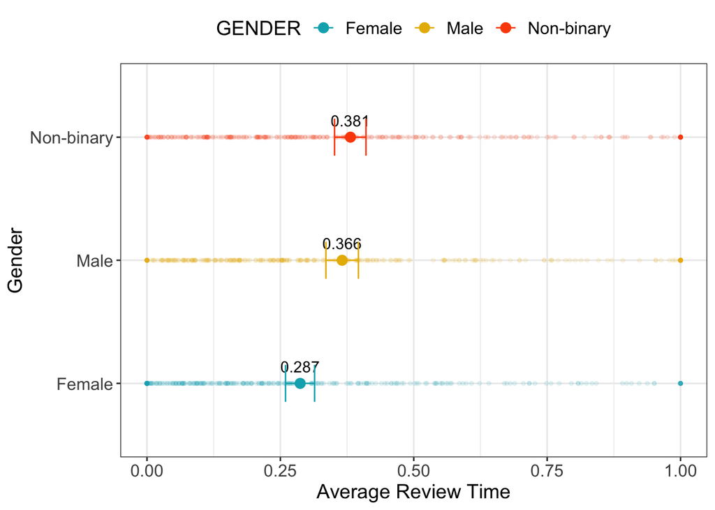

```r
h11<-ggplot()+
  geom_point(data=r1, aes(y=GENDER, x=aver_time, color=GENDER), size=3)+
  geom_text(data=r1, aes(label=format(round(aver_time, 3), nsmall=3),
                         x=aver_time, y=GENDER),hjust=0.5, vjust=-1)+
  geom_errorbar(data=r1, aes(x=aver_time,y=GENDER, xmin = low_CI, xmax = high_CI,
                             color=GENDER), width=0.3)+
  geom_point(data=h1, aes(y=GENDER, x=norm_total_before, color=GENDER),
             size=1, alpha=0.1)+
  labs(y="Gender", x="Average Review Time")+
  theme_bw()+
  scale_color_manual(values = c("#00AFBB", "#E7B800", "#FC4E07"))+
  theme(axis.text.x=element_text(size=12),
        axis.text.y=element_text(size=12),
        legend.text=element_text(size=12),
        text = element_text(size = 14),legend.position="top")
h11
```

```r
ggsave(file="H1.1.pdf", width=5, height=3.5)
```

## 2.2 H1.2.

Black applicants will get less review time than white applicants.

### 2.2.1 Delta Mean Time

Mean focus time (after normalization) by race:  
Black 0.3552549  
White 0.3340815

Delta mean time (W-B) is -0.02117, p-value=0.3047.

```r
r2<- h1 %>%
  group_by(RACE) %>%
  summarise(aver_time = mean(norm_total_before))
r2
```

```
## # A tibble: 2 × 2
##   RACE  aver_time
##   <chr>     <dbl>
## 1 Black     0.355
## 2 White     0.334
```

```r
print(paste0('Delta mean time (W-B) is ', r2[2,2]-r2[1,2]))
```

```
## [1] "Delta mean time (W-B) is -0.0211734040332798"
```

### 2.2.2 t-test

```r
# T-test: true difference exists

t.test(h1[h1$RACE=='Black',]$norm_total_before, h1[h1$RACE=='White',]$norm_total_before, var.equal=FALSE)
```

```
##
##  Welch Two Sample t-test
##
## data:  h1[h1$RACE == "Black", ]$norm_total_before and h1[h1$RACE == "White", ]$norm_total_before
## t = 1.027, df = 896.38, p-value = 0.3047
## alternative hypothesis: true difference in means is not equal to 0
## 95 percent confidence interval:
##  -0.01929056  0.06163737
## sample estimates:
## mean of x mean of y
## 0.3552549 0.3340815
```

### 2.2.3 Graph

Bootstrapping CI

```r
set.seed(10)
M <- 10000
# Empty matrix to save the values
delta_b <- matrix(NA, M)
delta_w <- matrix(NA, M)

for(i in 1:M){
  resample <- h1[sample(nrow(h1), replace = T),]
  boots_time_w <- mean(resample[resample$RACE=='White',]$norm_total_before)
  boots_time_b <- mean(resample[resample$RACE=='Black',]$norm_total_before)
  delta_w[i] <- boots_time_w
  delta_b[i] <- boots_time_b
}

se_w <- sd(delta_w)
se_b <- sd(delta_b)

q_val <- qt(0.95, M-1)
r2[r2$RACE == 'White', 'low_CI'] <- mean(delta_w) - q_val*se_w
r2[r2$RACE == 'Black', 'low_CI'] <- mean(delta_b) - q_val*se_b

r2[r2$RACE == 'White', 'high_CI'] <- mean(delta_w) + q_val*se_w
r2[r2$RACE == 'Black', 'high_CI'] <- mean(delta_b) + q_val*se_b

r2
```

```
## # A tibble: 2 × 4
##   RACE  aver_time low_CI high_CI
##   <chr>     <dbl>  <dbl>   <dbl>
## 1 Black     0.355  0.332   0.379
## 2 White     0.334  0.310   0.358
```

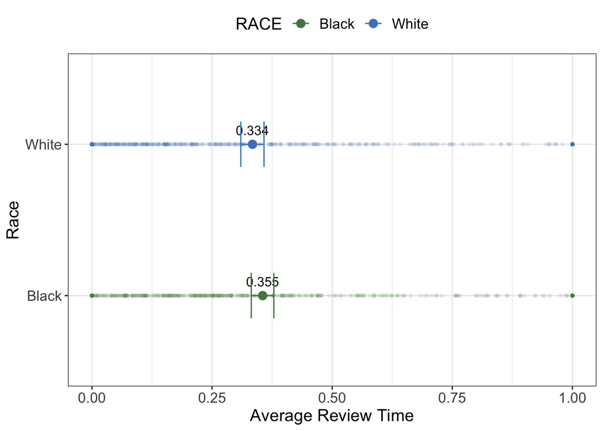

```r
h12<-ggplot()+
  geom_point(data=r2, aes(y=RACE, x=aver_time, color=RACE), size=3)+
  geom_text(data=r2, aes(label=format(round(aver_time, 3), nsmall=3),
                         x=aver_time, y=RACE),hjust=0.5, vjust=-1)+
  geom_errorbar(data=r2, aes(x=aver_time,y=RACE, xmin = low_CI, xmax = high_CI,
                             color=RACE), width=0.3)+
  geom_point(data=h1, aes(y=RACE, x=norm_total_before, color=RACE),
             size=1, alpha=0.1)+
  labs(y="Race", x="Average Review Time")+
  theme_bw()+
  scale_color_manual(values = c("#52854C", "#4E84C4"))+
  theme(axis.text.x=element_text(size=12),
        axis.text.y=element_text(size=12),
        legend.text=element_text(size=12),
        text = element_text(size = 14),legend.position="top")
h12
```

```r
ggsave(file="H1.2.pdf", width=4.5, height=3)
```

## 2.3 H1.3

Female and non-binary applicants will be rated lower than their equally-competent male counterparts.

### 2.3.1 Delta Mean Rating

Meaning rating (after normalization) by gender:  
Female 0.5236511  
Male 0.541660  
Non-binary 0.5335028  
Delta mean rating (M-F) is 0.01800, p-value=0.5394  
Delta mean rating (M-NB) is 0.00815, p-value=0.7836

```r
# calculate the mean ratings by gender
r3<- h1 %>%
  group_by(GENDER) %>%
  summarise(aver_rating = mean(norm_rating_before))
r3
```

```
## # A tibble: 3 × 2
##   GENDER     aver_rating
##   <chr>            <dbl>
## 1 Female           0.524
## 2 Male             0.542
## 3 Non-binary       0.534
```

```r
print(paste0('Delta mean rating (M-F) is ', r3[2,2]-r3[1,2]))
```

```
## [1] "Delta mean rating (M-F) is 0.0180097185496045"
```

```r
print(paste0('Delta mean rating (M-NB) is ', r3[2,2]-r3[3,2]))
```

```
## [1] "Delta mean rating (M-NB) is 0.00815802008432431"
```

### 2.3.2 t-test

```r
# T-test: whether true difference exists

# Male & Female
t.test(h1[h1$GENDER=='Male',]$norm_rating_before, h1[h1$GENDER=='Female',]$norm_rating_before, var.equal=FALSE)
```

```
##
##  Welch Two Sample t-test
##
## data:  h1[h1$GENDER == "Male", ]$norm_rating_before and h1[h1$GENDER == "Female", ]$norm_rating_before
## t = 0.61412, df = 596.87, p-value = 0.5394
## alternative hypothesis: true difference in means is not equal to 0
## 95 percent confidence interval:
##  -0.03958517  0.07560460
## sample estimates:
## mean of x mean of y
## 0.5416609 0.5236511
```

```r
# Male & non-binary
t.test(h1[h1$GENDER=='Male',]$norm_rating_before, h1[h1$GENDER=='Non-binary',]$norm_rating_before, var.equal=FALSE)
```

```
##
##  Welch Two Sample t-test
##
## data:  h1[h1$GENDER == "Male", ]$norm_rating_before and h1[h1$GENDER == "Non-binary", ]$norm_rating_before
## t = 0.27475, df = 596.94, p-value = 0.7836
## alternative hypothesis: true difference in means is not equal to 0
## 95 percent confidence interval:
##  -0.05015589  0.06647193
## sample estimates:
## mean of x mean of y
## 0.5416609 0.5335028
```

### 2.3.3 Graph

Bootstrapping CI

```r
set.seed(10)
M <- 10000
# Empty matrix to save the values
delta_m <- matrix(NA, M)
delta_f <- matrix(NA, M)
delta_nb <- matrix(NA, M)

for(i in 1:M){
  resample <- h1[sample(nrow(h1), replace = T),]
  boots_ratings_m <- mean(resample[resample$GENDER=='Male',]$norm_rating_before)
  boots_ratings_f <- mean(resample[resample$GENDER=='Female',]$norm_rating_before)
  boots_ratings_nb <- mean(resample[resample$GENDER=='Non-binary',]$norm_rating_before)
  delta_m[i] <- boots_ratings_m
  delta_f[i] <- boots_ratings_f
  delta_nb[i] <- boots_ratings_nb
}

se_m <- sd(delta_m)
se_f <- sd(delta_f)
se_nb <- sd(delta_nb)

q_val <- qt(0.95, M-1)
r3[r3$GENDER == 'Male', 'low_CI'] <- mean(delta_m) - q_val*se_m
r3[r3$GENDER == 'Female', 'low_CI'] <- mean(delta_f) - q_val*se_f
r3[r3$GENDER == 'Non-binary', 'low_CI'] <- mean(delta_nb) - q_val*se_nb

r3[r3$GENDER == 'Male', 'high_CI'] <- mean(delta_m) + q_val*se_m
r3[r3$GENDER == 'Female', 'high_CI'] <- mean(delta_f) + q_val*se_f
r3[r3$GENDER == 'Non-binary', 'high_CI'] <- mean(delta_nb) + q_val*se_nb

r3
```

```
## # A tibble: 3 × 4
##   GENDER     aver_rating low_CI high_CI
##   <chr>            <dbl>  <dbl>   <dbl>
## 1 Female           0.524  0.489   0.558
## 2 Male             0.542  0.507   0.576
## 3 Non-binary       0.534  0.499   0.568
```

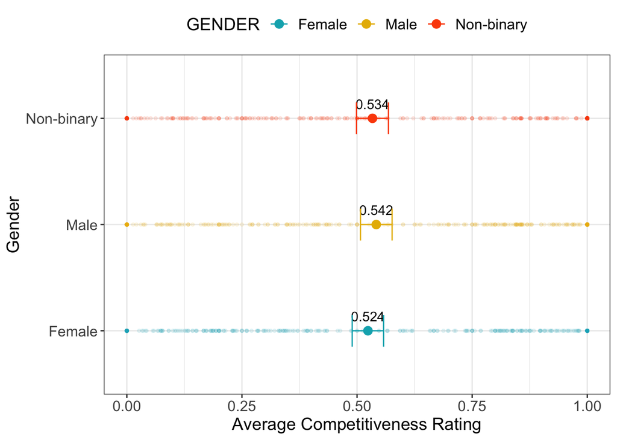

```r
h13<-ggplot()+
  geom_point(data=r3, aes(y=GENDER, x=aver_rating, color=GENDER), size=3)+
  geom_text(data=r3, aes(label=format(round(aver_rating, 3), nsmall=3),
                         x=aver_rating, y=GENDER),hjust=0.5, vjust=-1)+
  geom_errorbar(data=r3, aes(x=aver_rating,y=GENDER, xmin = low_CI, xmax = high_CI,
                             color=GENDER), width=0.3)+
  geom_point(data=h1, aes(y=GENDER, x=norm_rating_before, color=GENDER),
             size=1, alpha=0.1)+
  labs(y="Gender", x="Average Competitiveness Rating")+
  scale_color_manual(values = c("#00AFBB", "#E7B800", "#FC4E07"))+
  theme_bw()+
  theme(axis.text.x=element_text(size=12),
        axis.text.y=element_text(size=12),
        legend.text=element_text(size=12),
        text = element_text(size = 14),legend.position="top")
h13
```

```r
ggsave(file="H1.3.pdf", width=4.5, height=3.5)
```

## 2.4 H1.4

Black applicants will be rated lower than their equally-competent white counterparts.

### 2.4.1 Delta mean rating

Meaning rating by race:  
Black 0.5411733  
White 0.5246655

Delta mean rating (W-B) is -0.01651, p-value= 0.4931

```r
# calculate the mean ratings by gender
r4<- h1 %>%
  group_by(RACE) %>%
  summarise(aver_rating = mean(norm_rating_before))
r4
```

```
## # A tibble: 2 × 2
##   RACE  aver_rating
##   <chr>       <dbl>
## 1 Black       0.541
## 2 White       0.525
```

```r
print(paste0('Delta mean rating (W-B) is ', r4[2,2]-r4[1,2]))
```

```
## [1] "Delta mean rating (W-B) is -0.0165078571571825"
```

### 2.4.2 t-test

```r
# T-test: true difference exists

t.test(h1[h1$RACE=='Black',]$norm_rating_before, h1[h1$RACE=='White',]$norm_rating_before, var.equal=FALSE)
```

```
##
##  Welch Two Sample t-test
##
## data:  h1[h1$RACE == "Black", ]$norm_rating_before and h1[h1$RACE == "White", ]$norm_rating_before
## t = 0.6856, df = 896.77, p-value = 0.4931
## alternative hypothesis: true difference in means is not equal to 0
## 95 percent confidence interval:
##  -0.03074820  0.06376392
## sample estimates:
## mean of x mean of y
## 0.5411733 0.5246655
```

### 2.4.3 Graph

Bootstrapping CI

```r
set.seed(10)
M <- 10000
# Empty matrix to save the values
delta_b <- matrix(NA, M)
delta_w <- matrix(NA, M)

for(i in 1:M){
  resample <- h1[sample(nrow(h1), replace = T),]
  boots_ratings_b <- mean(resample[resample$RACE=='Black',]$norm_rating_before)
  boots_ratings_w <- mean(resample[resample$RACE=='White',]$norm_rating_before)
  delta_b[i] <- boots_ratings_b
  delta_w[i] <- boots_ratings_w
}

se_b <- sd(delta_b)
se_w <- sd(delta_w)

q_val <- qt(0.95, M-1)
r4[r4$RACE == 'White', 'low_CI'] <- mean(delta_w) - q_val*se_w
r4[r4$RACE == 'Black', 'low_CI'] <- mean(delta_b) - q_val*se_b

r4[r4$RACE == 'White', 'high_CI'] <- mean(delta_w) + q_val*se_w
r4[r4$RACE == 'Black', 'high_CI'] <- mean(delta_b) + q_val*se_b

r4
```

```
## # A tibble: 2 × 4
##   RACE  aver_rating low_CI high_CI
##   <chr>       <dbl>  <dbl>   <dbl>
## 1 Black       0.541  0.513   0.570
## 2 White       0.525  0.497   0.552
```

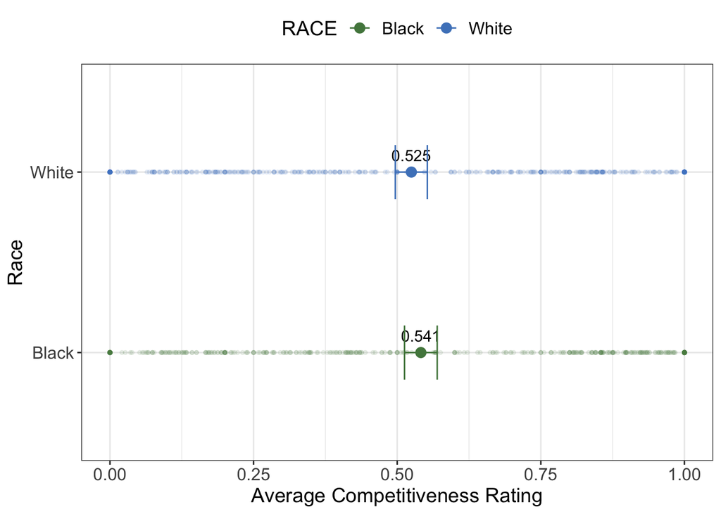

```r
h14<-ggplot()+
  geom_point(data=r4, aes(y=RACE, x=aver_rating, color=RACE), size=3)+
  geom_text(data=r4, aes(label=format(round(aver_rating, 3), nsmall=3),
                         x=aver_rating, y=RACE),hjust=0.5, vjust=-1)+
  geom_errorbar(data=r4, aes(x=aver_rating,y=RACE, xmin = low_CI, xmax = high_CI,
                             color=RACE), width=0.3)+
  geom_point(data=h1, aes(y=RACE, x=norm_rating_before, color=RACE),
             size=1, alpha=0.1)+
  labs(y="Race", x="Average Competitiveness Rating")+
  theme_bw()+
  scale_color_manual(values = c("#52854C", "#4E84C4"))+
  theme(axis.text.x=element_text(size=12),
        axis.text.y=element_text(size=12),
        legend.text=element_text(size=12),
        text = element_text(size = 14),legend.position="top")
h14
```

```r
ggsave(file="H1.4.pdf", width=4.5, height=3)
```

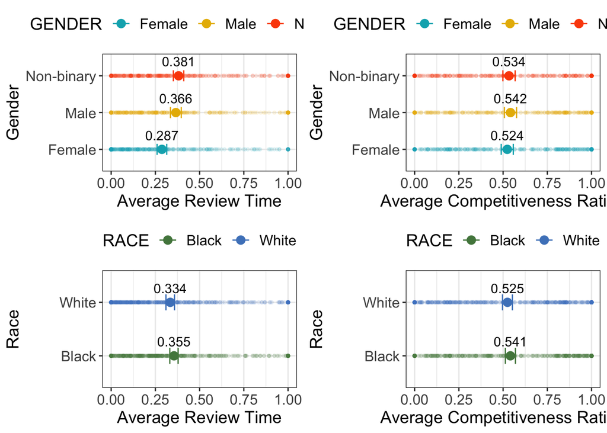

```r
library(ggpubr)
ggarrange(ggarrange(h11, h12,nrow=2, align = "v"), ggarrange(h13, h14,nrow=2,align = "v"),
           ncol = 2)
```

```r
ggsave(file="H1_combined.pdf", width=10.5, height=5.5)
```

# 3 H2

Participants’ review behavior (time spent) and decisions (ratings) will correlate with their implicit biases.

```r
h2 <- df
```

## 3.1 H2.1

Participants with higher gender IAT scores will spend less time on female and non-binary applicants than male applicants.

New variable defined as:  
`gender_time_diff1` = mean time on Male applicant - mean time on Female applicant  
`gender_time_diff2` = mean time on Male applicant - mean time on Non-binary applicant

Result:  
- M & F: For linear regression gender_time_diff1 ~ IAT_Score_Gender, slope = -0.06915, p-value=4.52e-05. Higher IAT score, more equally time spent between male & female applicants

- M & N-B: For linear regression gender_time_diff2 ~ IAT_Score_Gender, slope = 0.06450, p-value = 0.000404 Higher IAT score, spend more time on male applicants than on non-binary applicants

```r
c1 <- h2 %>%
  group_by(user_id, GENDER) %>%
  summarise(gender_mean_time=mean(norm_total_before))
for (i in 1:length(h2$user_id)) {
  user = h2$user_id[i]
  h2[h2$user_id==user, 'gender_time_diff1'] <- c1[c1$user_id==user & c1$GENDER=='Male', ]$gender_mean_time - c1[c1$user_id==user & c1$GENDER=='Female', ]$gender_mean_time
  h2[h2$user_id==user, 'gender_time_diff2'] <- c1[c1$user_id==user & c1$GENDER=='Male', ]$gender_mean_time - c1[c1$user_id==user & c1$GENDER=='Non-binary', ]$gender_mean_time
}
```

### 3.1.1 Male & Female

```r
mod.1 <- lm(gender_time_diff1 ~ IAT_Score_Gender, h2, na.action=na.omit)
summary(mod.1)
```

```
##
## Call:
## lm(formula = gender_time_diff1 ~ IAT_Score_Gender, data = h2,
##     na.action = na.omit)
##
## Residuals:
##      Min       1Q   Median       3Q      Max
## -0.54376 -0.13061  0.02042  0.15268  0.40818
##
## Coefficients:
##                   Estimate Std. Error t value Pr(>|t|)
## (Intercept)       0.098276   0.008675   11.33  < 2e-16 ***
## IAT_Score_Gender -0.069152   0.016865   -4.10 4.52e-05 ***
## ---
## Signif. codes:  0 '***' 0.001 '**' 0.01 '*' 0.05 '.' 0.1 ' ' 1
##
## Residual standard error: 0.1914 on 850 degrees of freedom
##   (47 observations deleted due to missingness)
## Multiple R-squared:  0.0194, Adjusted R-squared:  0.01824
## F-statistic: 16.81 on 1 and 850 DF,  p-value: 4.521e-05
```

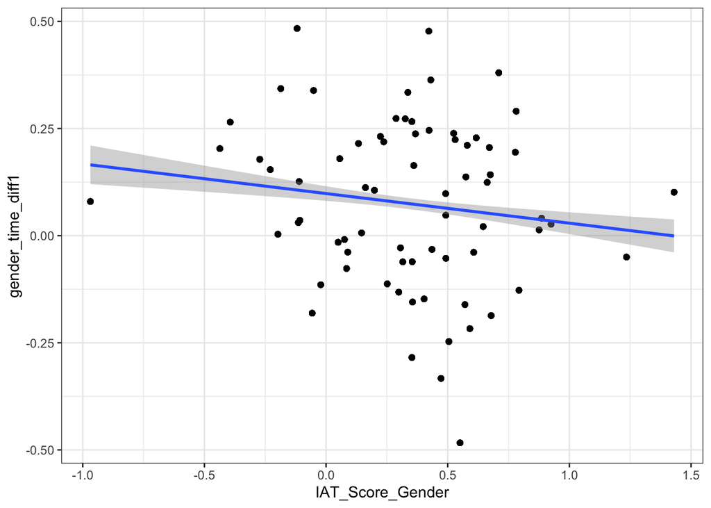

```r
h2 %>%
  ggplot(aes(x=IAT_Score_Gender,y=gender_time_diff1))+
  geom_point()+
  geom_smooth(method='lm')+
  theme_bw()
```

### 3.1.2 Male & Non-binary

```r
mod.2 <- lm(gender_time_diff2 ~ IAT_Score_Gender, h2, na.action=na.omit)
summary(mod.2)
```

```
##
## Call:
## lm(formula = gender_time_diff2 ~ IAT_Score_Gender, data = h2,
##     na.action = na.omit)
##
## Residuals:
##      Min       1Q   Median       3Q      Max
## -0.47323 -0.14357  0.00479  0.18614  0.36844
##
## Coefficients:
##                   Estimate Std. Error t value Pr(>|t|)
## (Intercept)      -0.029550   0.009342  -3.163 0.001616 **
## IAT_Score_Gender  0.064500   0.018160   3.552 0.000404 ***
## ---
## Signif. codes:  0 '***' 0.001 '**' 0.01 '*' 0.05 '.' 0.1 ' ' 1
##
## Residual standard error: 0.2061 on 850 degrees of freedom
##   (47 observations deleted due to missingness)
## Multiple R-squared:  0.01462,    Adjusted R-squared:  0.01346
## F-statistic: 12.62 on 1 and 850 DF,  p-value: 0.0004037
```

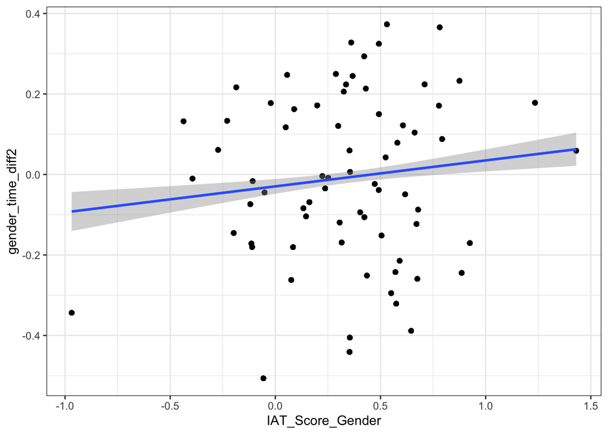

```r
h2 %>%
  ggplot(aes(x=IAT_Score_Gender,y=gender_time_diff2))+
  geom_point()+
  geom_smooth(method='lm')+
  theme_bw()
```

## 3.2 H2.2

Participants with higher race IAT scores will spend less time on black applicants than white applicants.

New variable defined as:  
`race_time_diff` = mean time on White applicant - mean time on Black applicant

Result:  
- For linear regression race_time_diff ~ IAT_Score_Race, slope = 0.117167, p-value=3.20e-15. Higher IAT score, spend more time on white applicants than on Black applicants

```r
c2 <- h2 %>%
  group_by(user_id, RACE) %>%
  summarise(race_mean_time=mean(norm_total_before))
for (i in 1:length(h2$user_id)) {
  user = h2$user_id[i]
  h2[h2$user_id==user, 'race_time_diff'] <- c2[c2$user_id==user & c2$RACE=='White', ]$race_mean_time - c2[c2$user_id==user & c2$RACE=='Black', ]$race_mean_time
}
```

```r
mod.3 <- lm(race_time_diff ~ IAT_Score_Race, h2, na.action=na.omit)
summary(mod.3)
```

```
##
## Call:
## lm(formula = race_time_diff ~ IAT_Score_Race, data = h2, na.action = na.omit)
##
## Residuals:
##      Min       1Q   Median       3Q      Max
## -0.43002 -0.09884  0.00811  0.12707  0.54422
##
## Coefficients:
##                 Estimate Std. Error t value Pr(>|t|)
## (Intercept)    -0.065486   0.008186  -8.000 4.06e-15 ***
## IAT_Score_Race  0.117167   0.014588   8.032 3.20e-15 ***
## ---
## Signif. codes:  0 '***' 0.001 '**' 0.01 '*' 0.05 '.' 0.1 ' ' 1
##
## Residual standard error: 0.1783 on 849 degrees of freedom
##   (48 observations deleted due to missingness)
## Multiple R-squared:  0.07062,    Adjusted R-squared:  0.06952
## F-statistic: 64.51 on 1 and 849 DF,  p-value: 3.2e-15
```

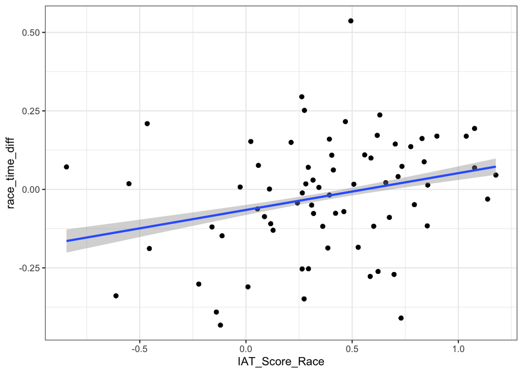

```r
h2 %>%
  ggplot(aes(x=IAT_Score_Race,y=race_time_diff))+
  geom_point()+
  geom_smooth(method='lm')+
  theme_bw()
```

## 3.3 H2.3

Participants with higher gender IAT scores will give lower ratings to female and non-binary applicants than male applicants.

New variable defined as:  
`gender_rating_diff1` = mean rating for Male applicant - mean rating for Female applicant  
`gender_rating_diff2` = mean rating for Male applicant - mean rating for Non-binary applicant

Result:

- M & F: For linear regression gender_rating_diff1 ~ IAT_Score_Gender, slope = -0.060320, p-value=1.38e-05. Higher IAT score, give higher ratings to female applicants than male applicants
- M & N-B: For linear regression gender_rating_diff2 ~ IAT_Score_Gender, slope = -0.033554, p-value = 0.002774. Higher IAT score, give higher ratings to non-binary applicants than male applicants

```r
c3 <- h2 %>%
  group_by(user_id, GENDER) %>%
  summarise(gender_mean_rating=mean(norm_rating_before))
for (i in 1:length(h2$user_id)) {
  user = h2$user_id[i]
  h2[h2$user_id==user, 'gender_rating_diff1'] <- c3[c3$user_id==user & c3$GENDER=='Male', ]$gender_mean_rating - c3[c3$user_id==user & c3$GENDER=='Female', ]$gender_mean_rating
  h2[h2$user_id==user, 'gender_rating_diff2'] <- c3[c3$user_id==user & c3$GENDER=='Male', ]$gender_mean_rating - c3[c3$user_id==user & c3$GENDER=='Non-binary', ]$gender_mean_rating
}
```

### 3.3.1 Male & Female

```r
mod.4 <- lm(gender_rating_diff1 ~ IAT_Score_Gender, h2, na.action=na.omit)
summary(mod.4)
```

```
##
## Call:
## lm(formula = gender_rating_diff1 ~ IAT_Score_Gender, data = h2,
##     na.action = na.omit)
##
## Residuals:
##      Min       1Q   Median       3Q      Max
## -0.36704 -0.08698 -0.01174  0.06299  0.65693
##
## Coefficients:
##                   Estimate Std. Error t value Pr(>|t|)
## (Intercept)       0.036906   0.007096   5.201 2.49e-07 ***
## IAT_Score_Gender -0.060320   0.013795  -4.373 1.38e-05 ***
## ---
## Signif. codes:  0 '***' 0.001 '**' 0.01 '*' 0.05 '.' 0.1 ' ' 1
##
## Residual standard error: 0.1566 on 850 degrees of freedom
##   (47 observations deleted due to missingness)
## Multiple R-squared:  0.022,  Adjusted R-squared:  0.02085
## F-statistic: 19.12 on 1 and 850 DF,  p-value: 1.379e-05
```

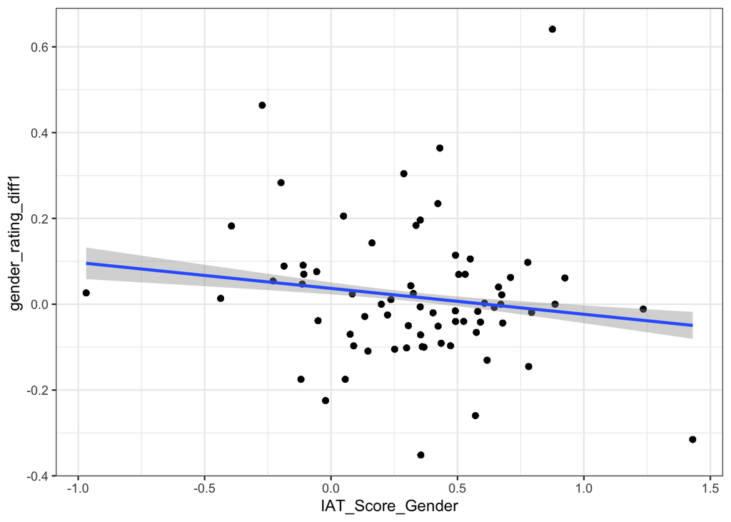

```r
h2 %>%
  ggplot(aes(x=IAT_Score_Gender,y=gender_rating_diff1))+
  geom_point()+
  geom_smooth(method='lm')+
  theme_bw()
```

### 3.3.2 Male & Non-binary

```r
mod.5 <- lm(gender_rating_diff2 ~ IAT_Score_Gender, h2, na.action=na.omit)
summary(mod.5)
```

```
##
## Call:
## lm(formula = gender_rating_diff2 ~ IAT_Score_Gender, data = h2,
##     na.action = na.omit)
##
## Residuals:
##      Min       1Q   Median       3Q      Max
## -0.29305 -0.07904 -0.00831  0.07738  0.30982
##
## Coefficients:
##                   Estimate Std. Error t value Pr(>|t|)
## (Intercept)       0.019227   0.005753   3.342 0.000867 ***
## IAT_Score_Gender -0.033554   0.011183  -3.000 0.002774 **
## ---
## Signif. codes:  0 '***' 0.001 '**' 0.01 '*' 0.05 '.' 0.1 ' ' 1
##
## Residual standard error: 0.1269 on 850 degrees of freedom
##   (47 observations deleted due to missingness)
## Multiple R-squared:  0.01048,    Adjusted R-squared:  0.009317
## F-statistic: 9.003 on 1 and 850 DF,  p-value: 0.002774
```

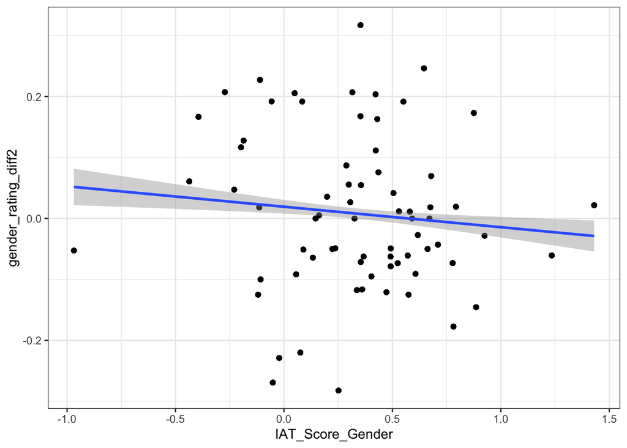

```r
h2 %>%
  ggplot(aes(x=IAT_Score_Gender,y=gender_rating_diff2))+
  geom_point()+
  geom_smooth(method='lm')+
  theme_bw()
```

## 3.4 H2.4

Participants with higher race IAT scores will give lower ratings to black applicants than white applicants.

New variable defined as:  
`race_rating_diff` = mean rating on White applicants - mean rating on Black applicants

Result:  
For linear regression race_rating_diff ~ IAT_Score_Race, slope = 0.090419, p-value= <2e-16. Higher IAT score, give higher ratings to white applicants than black applicants

```r
c4 <- h2 %>%
  group_by(user_id, RACE) %>%
  summarise(race_mean_rating=mean(norm_rating_before))
for (i in 1:length(h2$user_id)) {
  user = h2$user_id[i]
  h2[h2$user_id==user, 'race_rating_diff'] <- c4[c4$user_id==user & c4$RACE=='White', ]$race_mean_rating - c4[c4$user_id==user & c4$RACE=='Black', ]$race_mean_rating
}
```

```r
mod.6 <- lm(race_rating_diff ~ IAT_Score_Race, h2, na.action=na.omit)
summary(mod.6)
```

```
##
## Call:
## lm(formula = race_rating_diff ~ IAT_Score_Race, data = h2, na.action = na.omit)
##
## Residuals:
##      Min       1Q   Median       3Q      Max
## -0.27207 -0.05736  0.00643  0.08495  0.23161
##
## Coefficients:
##                 Estimate Std. Error t value Pr(>|t|)
## (Intercept)    -0.057240   0.005066  -11.30   <2e-16 ***
## IAT_Score_Race  0.090419   0.009029   10.01   <2e-16 ***
## ---
## Signif. codes:  0 '***' 0.001 '**' 0.01 '*' 0.05 '.' 0.1 ' ' 1
##
## Residual standard error: 0.1104 on 849 degrees of freedom
##   (48 observations deleted due to missingness)
## Multiple R-squared:  0.1056, Adjusted R-squared:  0.1046
## F-statistic: 100.3 on 1 and 849 DF,  p-value: < 2.2e-16
```

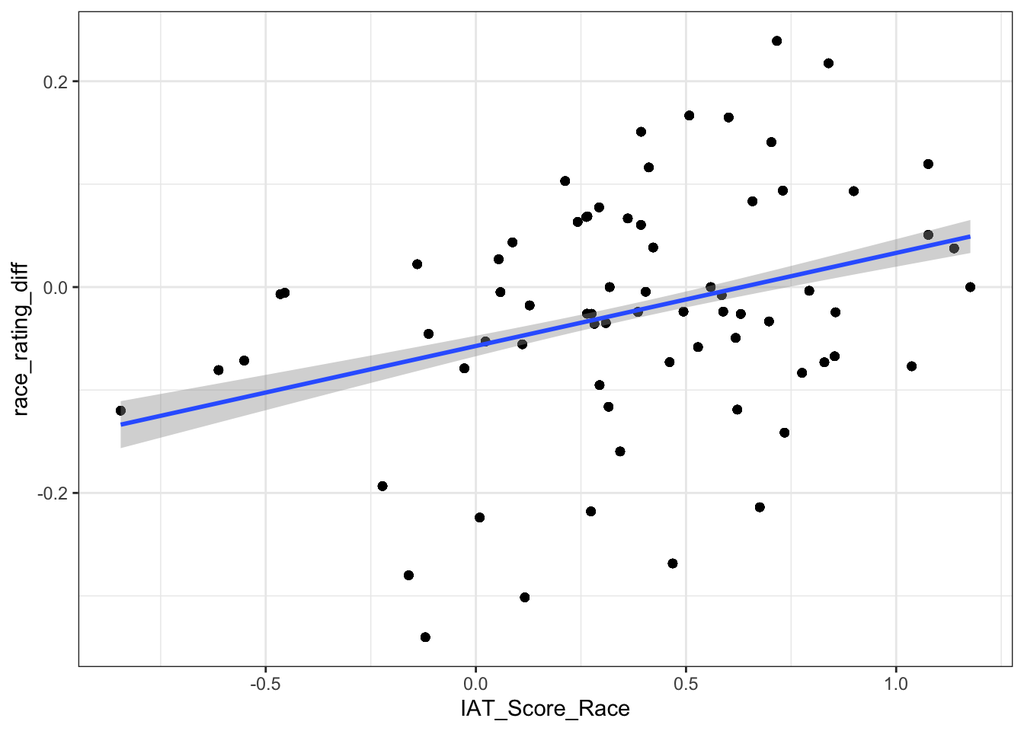

```r
h2 %>%
  ggplot(aes(x=IAT_Score_Race,y=race_rating_diff))+
  geom_point()+
  geom_smooth(method='lm')+
  theme_bw()
```